# Registros Red de Hospitales

Julia Cano Millán

2024-11-28

```r
library(DBI)
library(RPostgres)

con <- dbConnect(RPostgres::Postgres(),
                 dbname = "postgres",
                 host = "localhost",
                 port = 5432,
                 user = "postgres",
                 password = "Postgrejc31")
```

# Introducción

Esta base de datos ha sido creada a partir de **datos ficticios** generados aleatoriamente. Los **escenarios** que se plantean también son **ficticios**.

Se ha creado una base de datos de lo que podría ser una red de hospitales. Se detallan los ingresos de varios pacientes y de los tratamientos que les han sido administrados, además de quién ha administrado y distribuido los mismos; con, por supuesto, información más extensa de cada uno de los campos involucrados. Para ello se han creado cuatro tablas (o relaciones):

- *Tabla hospitales*: contiene datos de nueve hospitales en los que se han ingresado a ciertos pacientes.
- *Tabla médicos*: contiene datos de los médicos de cada hospital que han tratado a los pacientes seleccionados.
- *Tabla pacientes*: contiene datos de quince pacientes seleccionados de varios hospitales, y se explica el motivo de su ingreso.
- *Tabla tratamientos*: contiene los datos de los tratamientos aplicados, así como su precio y forma de distribución.

**Nota**: el contenido de las tablas será explicado cuando se presente cada tabla.

# Planteamiento de preguntas

Se han planteado tres preguntas que han sido resueltas mediante consultas en SQL:

- *Pregunta 1*: ¿Cuáles son los nombres de los pacientes que no van a sobrevivir a su ingreso?
- *Pregunta 2*: Las familias de los fallecidos, ¿deben denunciar por negligencia al hospital o a la empresa de transporte?
- *Pregunta 3*: ¿Cuál ha sido la causa de muerte de cada especialidad de las enfermedades de los pacientes, y cuántos casos ha habido de cada una?

# Metodología y resultados

## Creación de tablas

### Tabla hospitales

Esta tabla está compuesta por:

- El *nombre* de cada hospital, atributo que va a indentificar unívocamente los distintos hospitales de la base de datos ( *Clave Primaria*).
- La *cuidad* donde están ubicados. Los hospitales deben estar situados en algún lugar, sería imposible que no lo estuvieran, por ello, se ha aplicado la *restricción “NOT NULL”*.
- La *capacidad de camas* con la que cuenta el hospital. Esto es, el número de personas que pueden ser ingresadas a la vez en un hospital. Cualquier hospital debe de poder ingresar, mínimo, a una persona, por lo que debe tener al menos 1 cama, motivo por el cual se le ha aplicado la *restricción “CHECK”* corresponsiente.
- El *número de trabajadores* del hospital. Está claro que, al menos una persona debe trabajar en un hospital; por ello, a este atributo se le ha aplicado una *restricción “CHECK”*.
- La *especialidad* del hospital. Esto es, una especialidad médica en la que un hospital destaca entre las demás. Un ejemplo para una mejor comprensión: “El hospital [X] es el mejor de España en tratar afecciones cardiovasculares”.
- El *tratamiento* “estrella” del hospital, es, según la especialidad de cada hospital, el tratamiento que mejor saben realizar, es decir, el tratamiento con tasas de efectividad más altas de cada hospital. Un ejemplo para entender mejor este atributo: “El hospital [X] es el mejor de España en realizar transplantes de corazón”

```r
dbExecute(con, "
CREATE TABLE hospitales(
          nombre VARCHAR(70) PRIMARY KEY,
          ciudad VARCHAR(50) NOT NULL,
          capacidad_camas INTEGER CHECK (capacidad_camas > 0),
          n_trabajadores INTEGER CHECK (n_trabajadores > 0),
          especialidad VARCHAR(40) NOT NULL,
          tratamiento VARCHAR(50) NOT NULL
          );
          ")
```

```
## [1] 0
```

```r
dbExecute(con, "
          INSERT INTO hospitales VALUES
          ('Hospital Clínico San Carlos', 'Madrid', 1193, 5100, 'Cardiología', 'Trasplante cardíaco'),
          ('Hospital Universitario Vall de Hebrón', 'Barcelona', 1146, 9300, 'Psiquiatría', 'Estimulación magnética transcraneal'),
          ('Hospital Universitario de La Paz', 'Madrid', 1052, 6500, 'Gastroenterología', 'Endoscopia avanzada'),
          ('Hospital Virgen del Rocío', 'Sevilla', 1251, 10103, 'Neurología', 'Estimulación cerebral profunda'),
          ('Hospital Universitario de Canarias', 'Santa Cruz de Tenerife', 809, 6200, 'Oncología', 'Inmunoterapia'),
          ('Hospital Clínico Universitario de Valencia', 'Valencia', 582, 5400, 'Traumatología', 'Prótesis de rodilla'),
          ('Hospital Universitario de Salamanca', 'Salamanca', 863, 3734, 'Pediatría', 'Trasplante de médula ósea'),
          ('Hospital Universitario de La Coruña', 'A Coruña', 1090, 8000, 'Reumatología', 'Terapia celular para artritis'),
          ('Hospital Universitario de Navarra', 'Pamplona', 1077, 9186, 'Endocrinología', 'Trasplante de páncreas')
          ;
          ")
```

```
## [1] 9
```

```sql
SELECT * FROM hospitales
```

9 records

| nombre | ciudad | capacidad_camas | n_trabajadores | especialidad | tratamiento |
| --- | --- | --- | --- | --- | --- |
| Hospital Clínico San Carlos | Madrid | 1193 | 5100 | Cardiología | Trasplante cardíaco |
| Hospital Universitario Vall de Hebrón | Barcelona | 1146 | 9300 | Psiquiatría | Estimulación magnética transcraneal |
| Hospital Universitario de La Paz | Madrid | 1052 | 6500 | Gastroenterología | Endoscopia avanzada |
| Hospital Virgen del Rocío | Sevilla | 1251 | 10103 | Neurología | Estimulación cerebral profunda |
| Hospital Universitario de Canarias | Santa Cruz de Tenerife | 809 | 6200 | Oncología | Inmunoterapia |
| Hospital Clínico Universitario de Valencia | Valencia | 582 | 5400 | Traumatología | Prótesis de rodilla |
| Hospital Universitario de Salamanca | Salamanca | 863 | 3734 | Pediatría | Trasplante de médula ósea |
| Hospital Universitario de La Coruña | A Coruña | 1090 | 8000 | Reumatología | Terapia celular para artritis |
| Hospital Universitario de Navarra | Pamplona | 1077 | 9186 | Endocrinología | Trasplante de páncreas |

### Tabla médicos

Esta tabla está compuesta por:

- La *identificación* de cada médico, atributo que va a identificar y diferenciar a los distintos médicos ( *Clave Primaria*).
- El *nombre* de cada médico. No existe una persona sin nombre, por eso la *restricción “NOT NULL”*.
- La *edad* de cada médico. Un médico que trabaja en un hospital es una persona que ha estudiado medicina y tiene una especialidad, por lo que ha tenido que estudiar unos siete años antes de haber empezado a trabajar. De igual manera, un médico (al menos, en este “mundo” ficticio creado para este seminario) se jubila en torno a los sesenta años, por lo que no debería de haber médicos trabajando en los hospitales que superen esa edad. Es por esto por lo que se ha aplicado una *restricción “CHECK”*.
- El *hospital* en el que trabaja cada médico. Este atributo *referencia* al atributo *“nombre”* de la *tabla hospitales*, pues los médicos son trabajadores de los hospitales seleccionados en dicha tabla. Se han utilizado los *operadores “ON UPDATE CASCADE”* y *“ON DELETE CASCADE”* ya que es necesario que la información sea actualizada de una tabla a otra. Por ejemplo, si un hospital cambiase de nombre, debería cambiar en esta tabla también.
- Los *años de experiencia laboral* de cada médico.
- La *especialidad* de cada médico. Esto es lo mismo que la especialidad de cada hospital. La especialidad de un médico no tiene porqué coincidir con la de su hospital, pues en un hospital debe de haber médicos especializados en todos los campos posibles. En este escenario ficticio, es obligatorio que un médico esté especializado en algo, digamos que es como pertenecer a un departamento médico; por ello a este atributo se le ha aplicado la *restricción “NOT NULL”*.
- El *tratamiento* que mejor sabe realizar/aplicar cada médico. Significa lo mismo que el “tratamiento estrella” de cada hospital. Al igual que con el atributo anterior, es obligatorio que un médico sepa realizar un tratamiento mejor que los demás, por ello la *restricción “NOT NULL”*.

```r
dbExecute(con, "
          CREATE TABLE medicos(
          medico_id SERIAL PRIMARY KEY,
          nombre VARCHAR(40) NOT NULL,
          edad INTEGER CHECK (edad > 25 AND edad <= 60),
          hospital VARCHAR(70) REFERENCES hospitales(nombre) ON UPDATE CASCADE ON DELETE CASCADE,
          años_experiencia INTEGER,
          especialidad VARCHAR(40) NOT NULL,
          tratamiento_encargado VARCHAR(70) NOT NULL
          )
          ")
```

```
## [1] 0
```

```r
dbExecute(con, "
          INSERT INTO medicos VALUES
          (1, 'Ana García', 32, 'Hospital Clínico San Carlos', 5, 'Cardiología', 'Ablación por catéter'),
          (2, 'Carlos Martínez', 45, 'Hospital Universitario Vall de Hebrón', 10, 'Neurología', 'Estimulación magnética transcraneal repetitiva'),
          (3, 'Sofía Pérez', 58, 'Hospital Universitario de La Paz', 25, 'Oncología', 'Inmunoterapia por punto de control'),
          (4, 'David Suárez', 28, 'Hospital Virgen del Rocío', 2, 'Gastroenterología', 'Endoscopia con cápsula'),
          (5, 'Laura Fernández', 42, 'Hospital Universitario de Canarias', 15, 'Oftalmología', 'Cirugía de cataratas con láser femtosegundo'),
          (6, 'Pedro González', 35, 'Hospital Clínico Universitario de Valencia', 8, 'Traumatología', 'Artroscopia de rodilla'),
          (7, 'María Rodríguez', 60, 'Hospital Universitario de Salamanca', 30, 'Dermatología', 'Crioterapia para lesiones precancerosas'),
          (8, 'Juan Sánchez', 48, 'Hospital Universitario de La Coruña', 20, 'Urología', 'Cirugía laparoscópica de próstata'),
          (9, 'Isabel Ramírez', 55, 'Hospital Universitario de Navarra', 22, 'Ginecología', 'Histerectomía laparoscópica'),
          (10, 'Miguel Hernández', 29, 'Hospital Clínico San Carlos', 3, 'Psiquiatría', 'Terapia cognitivo-conductual'),
          (11, 'Marta López', 38, 'Hospital Universitario Vall de Hebrón', 28, 'Alergología', 'Inmunoterapia alergénica'),
          (12, 'Javier García', 52, 'Hospital Universitario de La Paz', 26, 'Reumatología', 'Inyecciones de ácido hialurónico'),
          (13, 'Ana Fernández', 26, 'Hospital Virgen del Rocío', 1, 'Radiología', 'Resonancia magnética nuclear'),
          (14, 'Carlos Rodríguez', 40, 'Hospital Universitario de Canarias', 14, 'Cardiología', 'Implante de marcapasos'),
          (15, 'Sofía Martínez', 36, 'Hospital Clínico Universitario de Valencia', 10, 'Endocrinología', 'Bomba de insulina');
          ")
```

```
## [1] 15
```

```sql
SELECT * FROM medicos
```

Displaying records 1 - 10

| medico_id | nombre | edad | hospital | años_experiencia | especialidad | tratamiento_encargado |
| --- | --- | --- | --- | --- | --- | --- |
| 1 | Ana García | 32 | Hospital Clínico San Carlos | 5 | Cardiología | Ablación por catéter |
| 2 | Carlos Martínez | 45 | Hospital Universitario Vall de Hebrón | 10 | Neurología | Estimulación magnética transcraneal repetitiva |
| 3 | Sofía Pérez | 58 | Hospital Universitario de La Paz | 25 | Oncología | Inmunoterapia por punto de control |
| 4 | David Suárez | 28 | Hospital Virgen del Rocío | 2 | Gastroenterología | Endoscopia con cápsula |
| 5 | Laura Fernández | 42 | Hospital Universitario de Canarias | 15 | Oftalmología | Cirugía de cataratas con láser femtosegundo |
| 6 | Pedro González | 35 | Hospital Clínico Universitario de Valencia | 8 | Traumatología | Artroscopia de rodilla |
| 7 | María Rodríguez | 60 | Hospital Universitario de Salamanca | 30 | Dermatología | Crioterapia para lesiones precancerosas |
| 8 | Juan Sánchez | 48 | Hospital Universitario de La Coruña | 20 | Urología | Cirugía laparoscópica de próstata |
| 9 | Isabel Ramírez | 55 | Hospital Universitario de Navarra | 22 | Ginecología | Histerectomía laparoscópica |
| 10 | Miguel Hernández | 29 | Hospital Clínico San Carlos | 3 | Psiquiatría | Terapia cognitivo-conductual |

### Tabla pacientes

Esta tabla la componen los siguientes atributos:

- El *DNI* de cada paciente. Este es el atributo que identificará a los diferentes pacientes ( *Clave Primaria*).
- El *nombre* de cada paciente. No existe una persona sin nombre, por ello la *restricción “NOT NULL”*.
- La *edad* en años de cada paciente. Los pacientes deben de tener una edad, aunque tengan meses de vida (0 años), es decir, sean bebés; por lo que se le ha aplicado una *restricción “CHECK”*.
- El *género* de cada paciente. Cada persona debe tener un género, aunque este no esté definido en los clásicos “Femenino” o “Masculino”, por ello la *restricción “CHECK”*.
- El *hospital* en el que está ingresado cada paciente. Este atributo *referencia* al atributo *“nombre”* de la *tabla hospitales*, pues los pacientes seleccionados están ingresados en los hospitales pertenecientes a dicha tabla. Se han utilizado los *operadores “ON UPDATE CASCADE”* y *“ON DELETE CASCADE”* ya que es necesario que la información sea actualizada de una tabla a otra, al igual que sucedía en la *tabla medicos*.
- La *identificación del médico* que trata a cada paciente. Este atributo *referencia* al atributo *“medico_id”* de la *tabla medicos*, ya que los médicos encargados de los pacientes son los seleccionados en dicha tabla. Se han utilizado los *operadores “ON UPDATE CASCADE”* y *“ON DELETE CASCADE”* ya que es necesario que la información sea actualizada de una tabla a otra, al igual que sucede en el atributo anterior.
- La *habitación* del hospital en la que está ingresado cada paciente. Un paciente ingresado debe estar ingresado en una habitación, por ello la *restricción “NOT NULL”*.
- La *enfermedad* (o afección) que sufre cada paciente, esto es, el motivo de su ingreso. Un paciente debe tener un motivo de ingreso, por lo que se ha aplicado la *restricción “NOT NULL”*.
- La *especialidad médica* a la que pertenece la enfermedad que sufre cada paciente. Cada afección debe estar clasificada en una determinada especialidad, por ello se aplica la *restricción “NOT NULL”*.

```r
dbExecute(con, "
    CREATE TABLE pacientes (
    DNI NUMERIC(8) PRIMARY KEY,
    nombre VARCHAR(100) NOT NULL,
    edad INTEGER CHECK (edad >= 0),
    genero VARCHAR(10) CHECK (genero IN ('Masculino', 'Femenino', 'Otro')),
    hospital VARCHAR(70) REFERENCES hospitales(nombre) ON UPDATE CASCADE ON DELETE CASCADE,
    id_medico INTEGER UNIQUE REFERENCES medicos(medico_id) ON UPDATE CASCADE ON DELETE CASCADE,
    habitacion INTEGER UNIQUE NOT NULL,
    enfermedad VARCHAR(100) NOT NULL,
    especialidad_enfermedad VARCHAR(100) NOT NULL
);
")
```

```
## [1] 0
```

```r
dbExecute(con, "
INSERT INTO pacientes VALUES
    (78523456, 'María Álvarez', 52, 'Femenino', 'Hospital Clínico San Carlos', 1, 312, 'Insuficiencia cardíaca congestiva', 'Cardiología'),
    (54321987, 'Juan González', 37, 'Masculino', 'Hospital Universitario Vall de Hebrón', 11, 205, 'Asma', 'Neumología'),
    (74895932, 'Laura Pérez', 28, 'Femenino', 'Hospital Virgen del Rocío', 13, 117, 'Úlcera', 'Gastroenterología'),
    (32109876, 'David López', 65, 'Masculino', 'Hospital Universitario Vall de Hebrón', 2, 428, 'Alzheimer', 'Neurología'),
    (65432109, 'Ana Martínez', 30, 'Femenino', 'Hospital Universitario de La Paz', 3, 501, 'Cáncer de mama', 'Oncología'),
    (12345678, 'Pedro Rodríguez', 72, 'Masculino', 'Hospital Universitario de Canarias', 14, 345, 'Infarto agudo de miocardio', 'Cardiología'),
    (87654321, 'Sofía Hernández', 14, 'Femenino', 'Hospital Universitario de Salamanca', 7, 229, 'Fibrosis quística', 'Neumología'),
    (43210987, 'Alejandro Fernández', 49, 'Masculino', 'Hospital Universitario de La Paz', 12, 183, 'Artritis', 'Reumatología'),
    (21098765, 'Isabel García', 60, 'Femenino', 'Hospital Universitario de La Coruña', 8, 456, 'Colitis', 'Gastroenterología'),
    (98765432, 'Antonio Moreno', 22, 'Masculino', 'Hospital Clínico Universitario de Valencia', 15, 370, 'Diabetes tipo 1', 'Endocrinología'),
    (76543210, 'Lucía Jiménez', 31, 'Femenino', 'Hospital Clínico San Carlos', 10, 264, 'Insomnio', 'Neurología'),
    (54321098, 'Miguel Sánchez', 80, 'Masculino', 'Hospital Virgen del Rocío', 4, 152, 'Accidente cerebrovascular', 'Cardiología'),
    (23784297, 'Carmen Ruiz', 45, 'Femenino', 'Hospital Clínico Universitario de Valencia', 6, 490, 'Fractura de fémur', 'Traumatología'),
    (10987654, 'José Navarro', 58, 'Masculino', 'Hospital Universitario de Navarra', 9, 237, 'Enfermedad pulmonar obstructiva crónica (EPOC)', 'Neumología'),
    (27834281, 'Paula Martín', 25, 'Femenino', 'Hospital Universitario de Canarias', 5, 381, 'Enfermedad de Crohn', 'Gastroenterología');
")
```

```
## [1] 15
```

```sql
SELECT * FROM pacientes
```

Displaying records 1 - 10

| dni | nombre | edad | genero | hospital | id_medico | habitacion | enfermedad | especialidad_enfermedad |
| --- | --- | --- | --- | --- | --- | --- | --- | --- |
| 78523456 | María Álvarez | 52 | Femenino | Hospital Clínico San Carlos | 1 | 312 | Insuficiencia cardíaca congestiva | Cardiología |
| 54321987 | Juan González | 37 | Masculino | Hospital Universitario Vall de Hebrón | 11 | 205 | Asma | Neumología |
| 74895932 | Laura Pérez | 28 | Femenino | Hospital Virgen del Rocío | 13 | 117 | Úlcera | Gastroenterología |
| 32109876 | David López | 65 | Masculino | Hospital Universitario Vall de Hebrón | 2 | 428 | Alzheimer | Neurología |
| 65432109 | Ana Martínez | 30 | Femenino | Hospital Universitario de La Paz | 3 | 501 | Cáncer de mama | Oncología |
| 12345678 | Pedro Rodríguez | 72 | Masculino | Hospital Universitario de Canarias | 14 | 345 | Infarto agudo de miocardio | Cardiología |
| 87654321 | Sofía Hernández | 14 | Femenino | Hospital Universitario de Salamanca | 7 | 229 | Fibrosis quística | Neumología |
| 43210987 | Alejandro Fernández | 49 | Masculino | Hospital Universitario de La Paz | 12 | 183 | Artritis | Reumatología |
| 21098765 | Isabel García | 60 | Femenino | Hospital Universitario de La Coruña | 8 | 456 | Colitis | Gastroenterología |
| 98765432 | Antonio Moreno | 22 | Masculino | Hospital Clínico Universitario de Valencia | 15 | 370 | Diabetes tipo 1 | Endocrinología |

### Tabla tratamientos

Esta tabla la componen los siguientes atributos:

- El *nombre* de cada tratamiento.
- Qué *tipo* de tratamiento es. Esto es, si es un medicamento, un aparato, una solución diluida, etc.
- A qué *especialidad* pertenece cada tratamiento. Por ejemplo: “Un marcapasos sirve para tratar afecciones cardiovasculares”.
- Los tres atributos anteriores son los que van a diferenciar los tipos de tratamiento ( *Clave Primaria Compuesta*).
- La *identificación del médico* que emplea cada tratamiento sobre su paciente. Este atributo *referencia* al atributo *“medico_id”* de la *tabla medicos* pues estos médicos son los que utilizan los tratamientos. Se han utilizado los *operadores “ON UPDATE CASCADE”* y *“ON DELETE CASCADE”* ya que es necesario que la información sea actualizada de una tabla a otra, al igual que sucedía con las anteriores referencias.
- El *precio* que cuestan los distintos tratamientos a los hospitales. No hay ningún tratamiento gratis (al menos, en este escenario ficticio), por lo que se ha impuesto una *restricción “NOT NULL”*.
- En qué *ciudad* se ha fabricado cada tratamiento.
- Mediante qué *medio de transporte* se ha distribuído el tratamiento desde su lugar de creación hasta el hospital correspondiente.
- Las *condiciones de transporte* que deben cumplirse en el transporte de cada tratamiento. Por ejemplo, si se transporta un aparato muy delicado, este debería ir protegido de impactos.
- Si se *cumplen o no las condiciones de transporte*. Habrá empresas de transporte que sean más descuidados transportando los tratamientos, por lo que puede que las condiciones no se cumplan y los tratamientos lleguen en mal estado. En este caso solo pueden cumplirse o no las condiciones (a no ser que un tratamiento no sea transportado, por lo que obviamente no tendrá condiciones de transporte), por lo que se ha especificado una *restricción “CHECK”*.

```r
dbExecute(con, "
          CREATE TABLE tratamientos (
          nombre VARCHAR(40),
          tipo VARCHAR(50),
          especialidad VARCHAR(30) NOT NULL,
          medico_responsable INTEGER REFERENCES medicos(medico_id) ON UPDATE CASCADE ON DELETE CASCADE,
          precio_euros INTEGER NOT NULL,
          ciudad_creación VARCHAR(50),
          transporte VARCHAR(40),
          condiciones_adecuadas VARCHAR(100),
          cumplen_condiciones CHAR(8) CHECK (cumplen_condiciones IN ('Sí', 'No', 'No tiene')),
          PRIMARY KEY(nombre, tipo, especialidad)
          );
          ")
```

```
## [1] 0
```

```r
dbExecute(con, "
          INSERT INTO tratamientos VALUES
          ('Catéter de radiofrecuencia', 'Aparato', 'Cardiología', 1, 10000, 'Boston, EE.UU.', 'Avión de carga', 'Refrigerado, protegido de impactos', 'No'),
          ('Dispositivo de TMS', 'Aparato', 'Neurología', 2, 100000, 'Shenzhen, China', 'Avión de carga', 'Embalaje especial, evitar vibraciones', 'Sí'),
          ('Inhibidor de punto de control PD-1', 'Medicamento', 'Oncología', 3, 10000, 'Basilea, Siuza', 'Avión de carga', 'Cadena de frío, protegido de la luz', 'Sí'),
          ('Cápsula endoscópica', 'Aparato deshechable', 'Gastroenterología', 4, 1500, 'Seúl, Corea del Sur', 'Avión de carga', 'Ambiente controlado, protegido de la humedad', 'Sí'),
          ('Láser femtosegundo', 'Aparato', 'Oftalmología', 5, 370000, 'Göttingen, Alemania', 'Avión de carga', 'Embalaje especial, evitar golpes', 'No'),
          ('Artroscopio', 'Instrumento', 'Traumatología', 6, 17500, 'Osaka', 'Avión de carga', 'Esterilizado, protegido de la humedad', 'Sí'),
          ('Nitrógeno líquido', 'Sustancia criogénica', 'Dermatología', 7, 750, 'Local', 'Camión refrigerado', null, 'No tiene'),
          ('Laparoscopio', 'Instrumento', 'Urología', 8, 17.500, 'Galway, Irlanda', 'Avión de carga', 'Esterilizado, empaquetado individualmente', 'No'),
          ('Laparoscopio', 'Instrumento', 'Ginecología', 9, 17500, 'Uppsala, Suecia', 'Avión de carga', 'Esterilizado, empaquetado individualmente', 'Sí'),
          ('Terapia de conversación', 'Servicio', 'Psiquiatría', 10, 150, null, null, null, 'No tiene'),
          ('Extractos alergénicos', 'Medicamento', 'Alergología', 11, 300, 'Viena, Austria', 'Avión de carga', 'Refrigerado, protegido de la luz', 'No'),
          ('Ácido hialurónico', 'Medicamento inyectable', 'Reumtología', 12, 1000, 'Seúl, Corea del Sur', 'Avión de carga', 'Refrigerado, protegido de la luz', 'Sí'),
          ('Equipo de resonancia magnética', 'Aparato', 'Radiología', 13, 2000000, 'Milwaukee, EE.UU.', 'Barco de carga', 'Manipulación especializada, evitar campos magnéticos', 'Sí'),
          ('Marcapasos', 'Aparato implantable', 'Cardiología', 14, 25000, 'Minneapolis, EE.UU.', 'Avión de carga', 'Esterilizado, protección contra rayos X', 'Sí'),
          ('Bomba de infusión de insulina', 'Aparato', 'Endocrinología', 15, 7500, 'París, Francia', 'Avión de carga', 'Refrigerado, protección contra impactos', 'No');
          ")
```

```
## [1] 15
```

```sql
SELECT * FROM tratamientos
```

Displaying records 1 - 10

| nombre | tipo | especialidad | medico_responsable | precio_euros | ciudad_creación | transporte | condiciones_adecuadas | cumplen_condiciones |
| --- | --- | --- | --- | --- | --- | --- | --- | --- |
| Catéter de radiofrecuencia | Aparato | Cardiología | 1 | 10000 | Boston, EE.UU. | Avión de carga | Refrigerado, protegido de impactos | No |
| Dispositivo de TMS | Aparato | Neurología | 2 | 100000 | Shenzhen, China | Avión de carga | Embalaje especial, evitar vibraciones | Sí |
| Inhibidor de punto de control PD-1 | Medicamento | Oncología | 3 | 10000 | Basilea, Siuza | Avión de carga | Cadena de frío, protegido de la luz | Sí |
| Cápsula endoscópica | Aparato deshechable | Gastroenterología | 4 | 1500 | Seúl, Corea del Sur | Avión de carga | Ambiente controlado, protegido de la humedad | Sí |
| Láser femtosegundo | Aparato | Oftalmología | 5 | 370000 | Göttingen, Alemania | Avión de carga | Embalaje especial, evitar golpes | No |
| Artroscopio | Instrumento | Traumatología | 6 | 17500 | Osaka | Avión de carga | Esterilizado, protegido de la humedad | Sí |
| Nitrógeno líquido | Sustancia criogénica | Dermatología | 7 | 750 | Local | Camión refrigerado | NA | No tiene |
| Laparoscopio | Instrumento | Urología | 8 | 18 | Galway, Irlanda | Avión de carga | Esterilizado, empaquetado individualmente | No |
| Laparoscopio | Instrumento | Ginecología | 9 | 17500 | Uppsala, Suecia | Avión de carga | Esterilizado, empaquetado individualmente | Sí |
| Terapia de conversación | Servicio | Psiquiatría | 10 | 150 | NA | NA | NA | No tiene |

## Respuesta a las preguntas

### Pregunta 1:

Si a un paciente le trata un médico cuya especialidad no se corresponde con el tipo de enfermedad del paciente, este médico no sabrá tartar su enfermedad, por lo que el paciente morirá. De igual manera, si se utiliza un tratamiento cuyas condiciones de transporte no se han cumplido, es decir, está en mal estado, el paciente también morirá. ¿Cuáles son los **nombres** de los **pacientes** que **no** van a sobrevivir a su ingreso?

```sql
DROP VIEW IF EXISTS fallecidos;
```

```sql
CREATE VIEW fallecidos AS
SELECT pacientes.nombre
FROM medicos JOIN pacientes
ON (medico_id = id_medico
AND medicos.especialidad != pacientes.especialidad_enfermedad)
UNION
SELECT pacientes.nombre
FROM pacientes JOIN tratamientos ON (id_medico = medico_responsable
AND cumplen_condiciones = 'No');
```

```sql
SELECT * FROM fallecidos
```

Displaying records 1 - 10

| nombre |
| --- |
| Antonio Moreno |
| María Álvarez |
| Miguel Sánchez |
| Isabel García |
| José Navarro |
| Sofía Hernández |
| Laura Pérez |
| Lucía Jiménez |
| Paula Martín |
| Juan González |

### Pregunta 2

Las familias de los **fallecidos**, ¿deben **denunciar** por negligencia al **hospital o** a la **empresa de transporte**?

```sql
SELECT 'La familia de '|| fallecidos.nombre || ' ' || 'denunciará' AS denuncia_familia,
    CASE
        WHEN (cumplen_condiciones = 'No'
            AND medicos.especialidad != pacientes.especialidad_enfermedad)
            THEN ' a ambos'
        WHEN (cumplen_condiciones = 'Sí'
            AND medicos.especialidad != pacientes.especialidad_enfermedad)
            THEN ' al hospital'
        WHEN (cumplen_condiciones = 'No'
            AND medicos.especialidad = pacientes.especialidad_enfermedad)
            THEN ' a la empresa de transporte'
        ELSE 'al hospital'
    END AS negligentes
FROM fallecidos LEFT JOIN pacientes USING(nombre)
JOIN medicos ON (medico_id = id_medico)
JOIN tratamientos ON (id_medico = medico_responsable)
```

Displaying records 1 - 10

| denuncia_familia | negligentes |
| --- | --- |
| La familia de María Álvarez denunciará | a la empresa de transporte |
| La familia de Miguel Sánchez denunciará | al hospital |
| La familia de Paula Martín denunciará | a ambos |
| La familia de Sofía Hernández denunciará | al hospital |
| La familia de Isabel García denunciará | a ambos |
| La familia de José Navarro denunciará | al hospital |
| La familia de Lucía Jiménez denunciará | al hospital |
| La familia de Juan González denunciará | a ambos |
| La familia de Laura Pérez denunciará | al hospital |
| La familia de Antonio Moreno denunciará | a la empresa de transporte |

### Pregunta 3

¿Cuál ha sido la **causa de muerte** de cada **especialidad** de las enfermedades de los pacientes, y **cuántos casos** ha habido de cada una?

```sql
SELECT especialidad_enfermedad,
    CASE
        WHEN medicos.especialidad != especialidad_enfermedad AND cumplen_condiciones = 'Sí'
            THEN 'Error médico'
        WHEN cumplen_condiciones = 'No' AND medicos.especialidad = especialidad_enfermedad
            THEN 'Fallo en el tratamiento'
        WHEN cumplen_condiciones = 'No' AND medicos.especialidad != especialidad_enfermedad
            THEN 'Ambos motivos'
        ELSE 'Error médico'
    END AS causa,
    COUNT(*) AS numero_casos
FROM fallecidos JOIN pacientes USING(nombre)
JOIN medicos ON id_medico = medico_id
JOIN tratamientos ON id_medico = medico_responsable
GROUP BY especialidad_enfermedad, causa
ORDER BY especialidad_enfermedad DESC;
```

8 records

| especialidad_enfermedad | causa | numero_casos |
| --- | --- | --- |
| Neurología | Error médico | 1 |
| Neumología | Ambos motivos | 1 |
| Neumología | Error médico | 2 |
| Gastroenterología | Ambos motivos | 2 |
| Gastroenterología | Error médico | 1 |
| Endocrinología | Fallo en el tratamiento | 1 |
| Cardiología | Error médico | 1 |
| Cardiología | Fallo en el tratamiento | 1 |

# Esquema de la base de datos

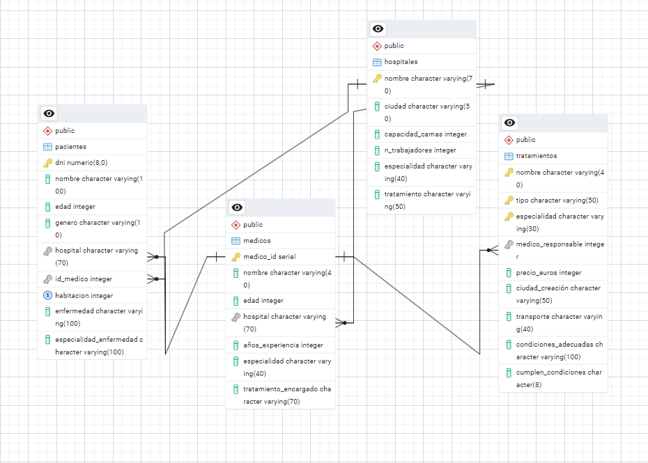

# Borrado de las tablas

```r
# Obtener la lista de todas las tablas en la base de datos
tables <- dbListTables(con)
print(tables)
```

```
## [1] "hospitales"   "medicos"      "pacientes"    "tratamientos" "fallecidos"
```

```r
# Borrar todas las tablas
for (table in tables) {
  dbExecute(con, paste0("DROP TABLE IF EXISTS ", table, " CASCADE;"))
}

# Verificar que no queden tablas
tables_after <- dbListTables(con)
print(tables_after)
```

```
## character(0)
```

Finalmente, desconectamos la base de datos local.

```r
dbDisconnect(con)
```